# Marketing Analytics

Chapter 5 · Learning from Observational Data

Nils Wlömert

Vienna University of Economics and Business (WU)

October 2026

# Part 1 · Observational data I

## Before we start

**Paper quiz on Chapter 4** *(10 min)*

- Individual, closed book
- Counts toward participation

**Assignment 2** is running

- Deadline: Group A Sun, Nov 8 · Group B Wed, Nov 11
- Debrief at the start of next session

## Today’s session

**Observational data I** *(today)*

5.1 Smart Mix without randomization  
5.2 From correlation to a line  
5.3 Reading a regression  
5.4 Adjusting for confounders  
5.5 Categorical predictors  
5.6 Prediction vs. explanation

**Observational data II** *(next session)*

5.7 Functional form and elasticities  
5.8 Logistic regression  
5.9 Diagnostics that change decisions  
5.10 Difference-in-differences

**Driving question:** *What if we cannot randomize?*

# 5.1 Smart Mix without randomization

## A different history

- Chapter 4: A/B test, 400 users → **+3.2 hours**
- Now: no experiment. Smart Mix launched as an **opt-in** feature
- Four weeks later: data of **2,000 users**, 653 adopters

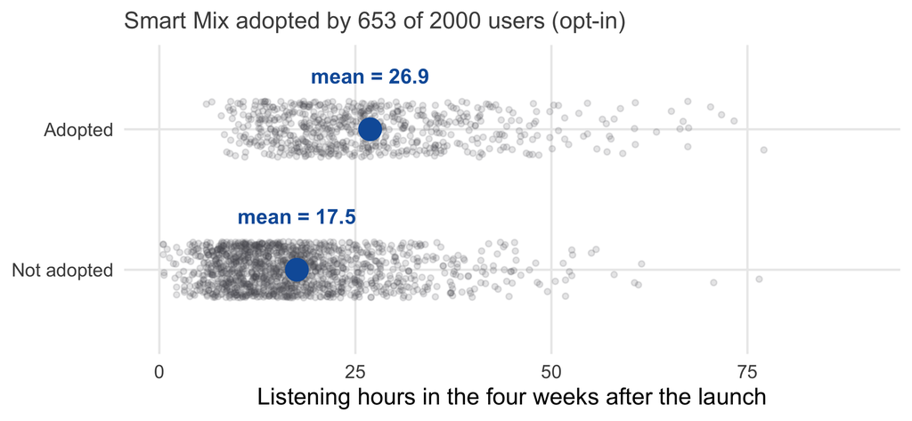

The dashboard says: adopters listen **9.3 hours more** — three times the experimental effect. Would you report this number to management?

## Adopters were different before Smart Mix existed

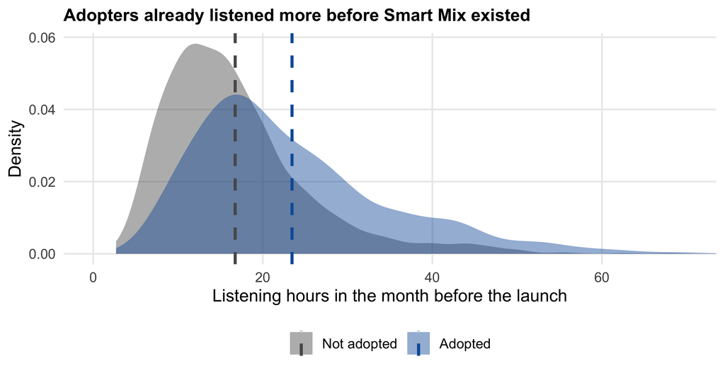

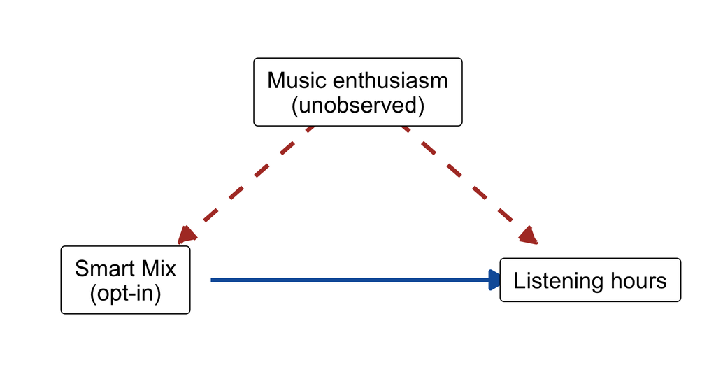

Same costume, new villain: **music enthusiasm** drives adoption *and* listening. Without a coin flip, we have one tool left: **adjustment**.

# 5.2 From correlation to a line

## Two variables, one line

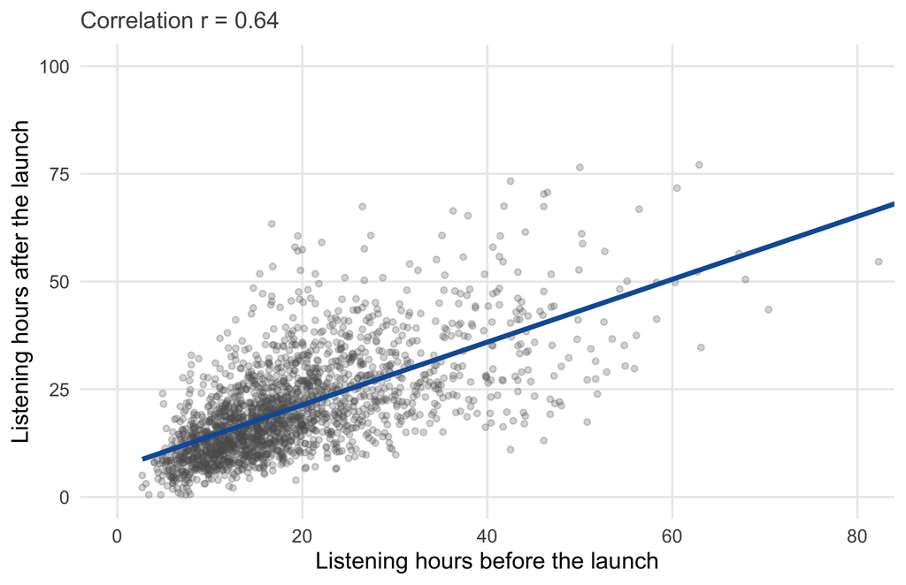

$$\text{hours} = \beta_0 + \beta_1 \cdot \text{prior hours} + \varepsilon$$

- $\beta_0$ **intercept** · $\beta_1$ **slope** · $\varepsilon$ **residual**
- Correlation: *that* they move together · regression: *how much*

```r
coef(lm(hours ~ prior_hours, data = smartmix_obs))
```

```
(Intercept) prior_hours
     6.7849      0.7291
```

Each extra hour before the launch **goes with** 0.73 hours after it — *goes with*, not *causes*.

## Which line? Least squares

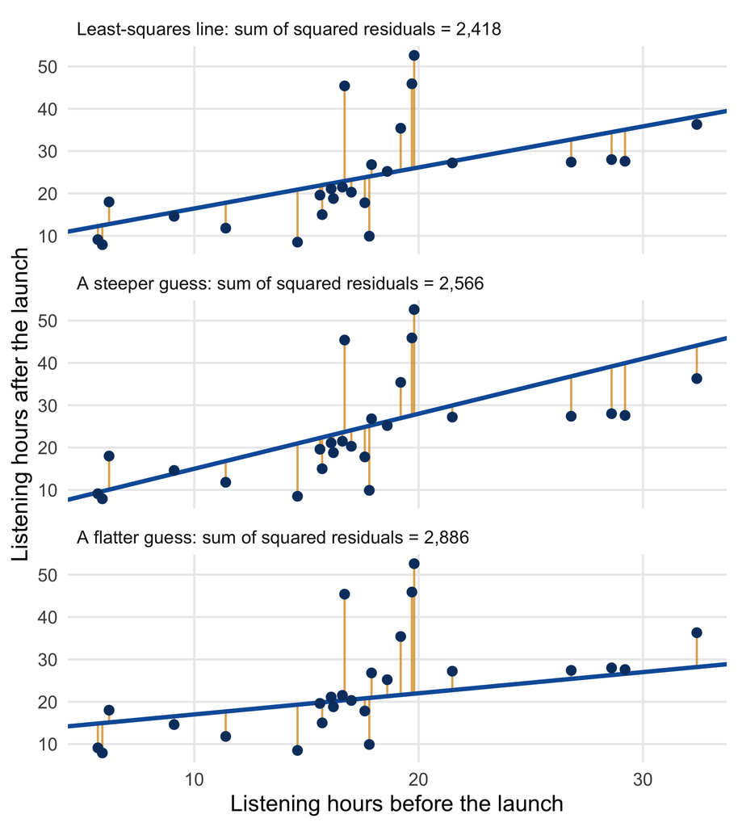

- Residual = observed − predicted (orange segments)
- The regression line **minimizes the sum of squared residuals**
- Squaring: big misses count a lot; above and below the line count alike
- `lm()` = “linear model”: does exactly this

**Live demo:** fit the line yourself — course book, §5.2

https://wu-rds.github.io/MA2026/05-observational-data.html#sec-obs-line

# 5.3 Reading a regression

## The full output

```r
model_naive <- lm(hours ~ smart_mix, data = smartmix_obs)
summary(model_naive)
```

```
Call:
lm(formula = hours ~ smart_mix, data = smartmix_obs)

Residuals:
   Min     1Q Median     3Q    Max
-20.88  -7.64  -2.06   4.76 101.22

Coefficients:
            Estimate Std. Error t value Pr(>|t|)
(Intercept)   17.541      0.300    58.5   <2e-16 ***
smart_mix      9.341      0.525    17.8   <2e-16 ***
---
Signif. codes:  0 '***' 0.001 '**' 0.01 '*' 0.05 '.' 0.1 ' ' 1

Residual standard error: 11 on 1998 degrees of freedom
Multiple R-squared:  0.137, Adjusted R-squared:  0.136
F-statistic:  316 on 1 and 1998 DF,  p-value: <2e-16
```

## Line by line

[output not shown]

With one 0/1 predictor, the regression **is** the comparison of two means — and its *t*-test is the two-sample *t*-test. `confint(model_naive)` gives the confidence intervals.

# 5.4 Adjusting for confounders

## Holding prior listening constant

```r
model_prior <- lm(hours ~ smart_mix + prior_hours, data = smartmix_obs)
coef_table(model_prior)
```

```
            Estimate Std. Error t value p-value
(Intercept)    6.451      0.412   15.65 < 0.001
smart_mix      4.901      0.443   11.08 < 0.001
prior_hours    0.662      0.020   33.17 < 0.001
```

The Smart Mix coefficient drops from **9.3** to **4.9**: now the difference between adopters and non-adopters **with the same prior listening**. Part of the naive gap belonged to prior listening — and is now attributed to it.

## More variables, same logic

```r
model_full <- lm(hours ~ smart_mix + prior_hours + tenure + premium + device, data = smartmix_obs)
coef_table(model_full)
```

```
              Estimate Std. Error t value p-value
(Intercept)      6.255      0.540   11.58 < 0.001
smart_mix        4.472      0.437   10.22 < 0.001
prior_hours      0.613      0.021   29.69 < 0.001
tenure           0.038      0.011    3.34 < 0.001
premium          2.924      0.426    6.87 < 0.001
deviceAndroid   -1.475      0.422   -3.49 < 0.001
deviceDesktop   -2.488      0.576   -4.32 < 0.001
```

Each coefficient: the association with the outcome **holding all other variables in the model constant**. Tenure, Premium and device change little: ≈ **4.5 hours**.

## Naive, adjusted — and the truth

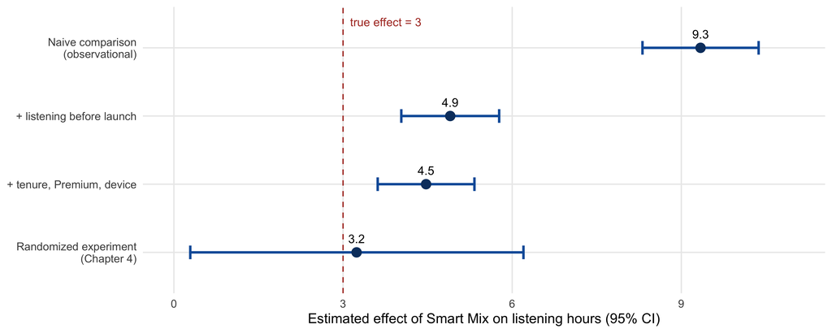

Adjustment removed ~75% of the bias — **not all of it**. We adjusted for a *proxy* of enthusiasm, not for enthusiasm. Regression removes exactly the confounding your variables capture.

## Live demo: how good must a proxy be?

Course book, §5.4 — set the **quality of the proxy** and the **strength of confounding**.

https://wu-rds.github.io/MA2026/05-observational-data.html#sec-obs-adjust

With a 50% proxy, how much of the bias is left? And what happens at 0%?

## Two warnings

**Adjusting for the wrong variable makes it worse.** A **mediator** (on the causal path) absorbs part of the effect you want. Only **confounders** — determined *before* the treatment, affecting treatment *and* outcome — belong in the model.

**“Enough” is untestable.** The assumption of no unobserved confounders cannot be checked in the data. Report *what* you adjusted for — and what you plausibly could not.

## Your turn (5 min)

Add **`age`** to the full model. Does the Smart Mix coefficient change? Why (not)?

```r
model_age <- lm(hours ~ smart_mix + prior_hours + tenure + premium + device + age,
                data = smartmix_obs)
coef_table(model_age)
```

Then: which variable in the data set should you **never** adjust for when estimating the effect of Smart Mix on listening — and why?

# 5.5 Categorical predictors

## Dummies and the reference category

```r
coef(model_full)[c("premium", "deviceAndroid", "deviceDesktop")]
```

```
      premium deviceAndroid deviceDesktop
        2.924        -1.475        -2.488
```

- **0/1 variable** (`premium`): coefficient = difference between the two groups, other variables held constant
- **Several categories** (`device`): R picks a **reference** (first level: iOS) and creates one **dummy** per other category
- Each dummy = difference to the **reference**

Android users: **1.5 hours less** than iOS users; Desktop: **2.5 hours less** — holding everything else constant. *p*-values compare each category with the reference; “does device matter at all?” → `anova(model_without, model_full)` (the ANOVA of Chapter 4).

# 5.6 Prediction vs. explanation

## Predicting listening time for new users

```r
set.seed(42)
train_ids <- sample(nrow(smartmix_obs), 1500)
train <- smartmix_obs[train_ids, ]
test  <- smartmix_obs[-train_ids, ]
model_pred <- lm(hours ~ prior_hours + tenure + premium +
                   device + smart_mix, data = train)
test$predicted <- predict(model_pred, newdata = test)
sqrt(mean((test$hours - test$predicted)^2))   # RMSE
```

```
[1] 9.425
```

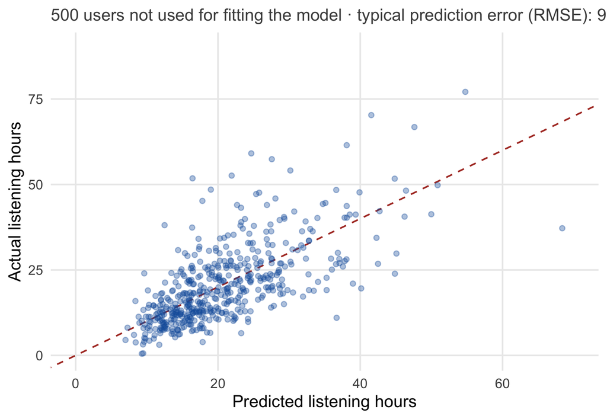

For **prediction**, it does not matter *why* a variable is associated with the outcome — only how well the predictions hold up on **data the model has not seen**.

## Two questions, two rules

**Explanation** (causal question): include confounders, exclude mediators, state what is unobserved. The **coefficient** matters; R² is secondary.

**Prediction**: include whatever predicts; judge by **out-of-sample errors**. Coefficients are not interpreted; the **predictions** matter.

A model can be a **good predictor and a bad explainer** at the same time. Where in your company would each mistake — reading causal effects off a prediction model, or judging a causal model by its R² — cost money?

## Learning check (Part I)

1. Slope of hours on prior hours = 0.73. Interpret — and why is it not causal?
2. Adding a variable can increase, decrease, or leave the Smart Mix coefficient unchanged. When does each happen?
3. `planFamily` = 4.2 with reference “Free”. Interpret. How do you test whether the plan matters at all?
4. R² = 0.71 for predicting next month’s spending with 25 predictors on 300 customers. What do you ask?

## Next session

**Observational data II** — beyond the straight line, and a quasi-experiment

- Functional form: when a line is wrong — **elasticities**
- Yes/no outcomes: logistic regression
- The three diagnostics that change decisions
- **Difference-in-differences** with real playlist data

Before next session: work through §5.1–5.6 on the course site. **Debrief of Assignment 2** at the start of the session.

# Part 2 · Observational data II

## Before we start

**Debrief Assignment 2** — analyzing experiments *(10 min)*

- Three short paper questions about *your* results
- Closed book, no laptop

**Paper quiz on Chapter 5, Part I** *(§5.1–5.6, 8 min)*

- Individual, closed book
- Counts toward participation

# 5.7 Functional form: when the line is wrong

## Diminishing returns

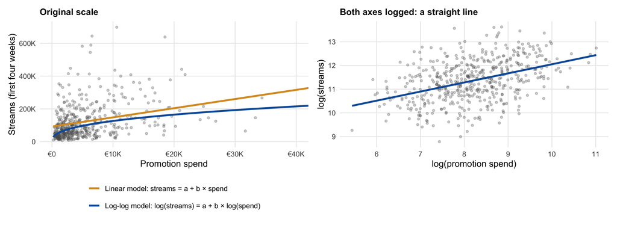

500 promotion campaigns: the first euros buy many streams, later euros fewer. A straight line cannot bend — on **log scales**, the cloud becomes a line again.

## The log-log model: elasticities

```r
model_loglog <- lm(log(streams) ~ log(spend) + log(followers) + placements + genre, data = campaigns)
coef_table(model_loglog)
```

```
                   Estimate Std. Error t value p-value
(Intercept)           2.881      0.235   12.28 < 0.001
log(spend)            0.331      0.021   16.00 < 0.001
log(followers)        0.507      0.016   32.28 < 0.001
placements            0.120      0.012   10.07 < 0.001
genreHipHop/Rap       0.199      0.048    4.19 < 0.001
genreRock            -0.256      0.060   -4.27 < 0.001
genreElectro/Dance    0.103      0.059    1.73   0.085
```

`log(spend)` = **0.33**: a 1% increase in spend goes with 0.33% more streams; +10% spend → **+3.3% streams** — the same *percentage* at every budget. Elasticities have no units and are **comparable**: followers (0.51) matter more than the budget.

## Four ways to combine levels and logs

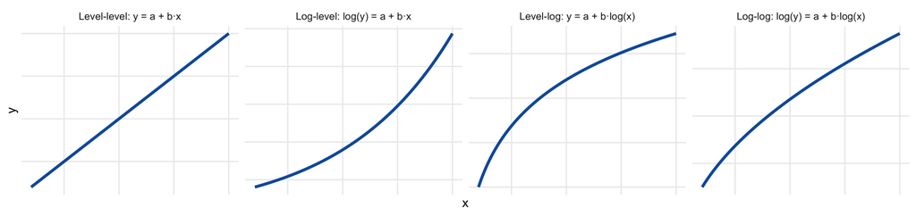

| Model | Equation | Reading $\beta_1$ |
| --- | --- | --- |
| Level-level | $y = \beta_0 + \beta_1 x$ | +1 unit $x$ → $\beta_1$ units of $y$ |
| Log-level | $\log y = \beta_0 + \beta_1 x$ | +1 unit $x$ → ≈ $100\beta_1$% of $y$ (exact: $100(e^{\beta_1}-1)$%) |
| Level-log | $y = \beta_0 + \beta_1 \log x$ | +1% $x$ → ≈ $\beta_1/100$ units of $y$ |
| Log-log | $\log y = \beta_0 + \beta_1 \log x$ | +1% $x$ → ≈ $\beta_1$% of $y$ (**elasticity**) |

## Your turn (5 min)

From the log-log model:

1. `genreHipHop/Rap` = 0.20. By what percentage do HipHop/Rap campaigns differ from Pop campaigns (the reference) — approximately and exactly?
2. A marketing manager proposes to double the promotion budget of every campaign. By roughly what percentage would streams increase, according to the model? Is this a causal claim?

## Live demo: linear or log-log?

Course book, §5.7 — move the **true elasticity**.

https://wu-rds.github.io/MA2026/05-observational-data.html#sec-obs-form

Elasticity **< 1**: diminishing returns, the line misses at both ends. **= 1**: proportional. **> 1**: increasing returns (rare — network effects).

# 5.8 Yes/no outcomes: logistic regression

## Why not a straight line?

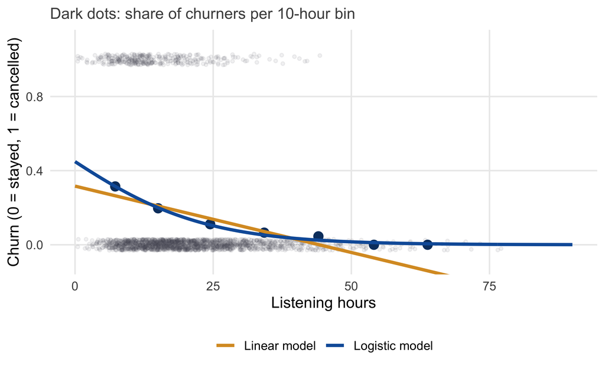

- Outcome: **churn** (cancelled within 3 months), 17% of users
- A line produces probabilities **below 0** for heavy listeners
- The **logistic** curve stays between 0 and 1 — and bends where it matters

```r
model_churn <- glm(churn ~ hours + premium + tenure + smart_mix,
                   family = binomial, data = smartmix_obs)
```

## Reading the coefficients: through probabilities

```r
model_churn <- glm(churn ~ hours + premium + tenure + smart_mix, family = binomial, data = smartmix_obs)
coef_table(model_churn)
```

```
            Estimate Std. Error z value p-value
(Intercept)    0.277      0.161    1.72   0.086
hours         -0.061      0.009   -7.13 < 0.001
premium       -0.533      0.153   -3.49 < 0.001
tenure        -0.020      0.004   -5.45 < 0.001
smart_mix     -0.256      0.162   -1.58   0.114
```

```r
typical_user <- data.frame(hours = c(10, 20, 30), premium = 0,
                           tenure = 24, smart_mix = 0)
predict(model_churn, newdata = typical_user, type = "response")
```

```
     1      2      3
0.3057 0.1936 0.1157
```

Read **sign** and **significance** directly; read **size** through **predicted probabilities**: 10 vs. 30 hours → churn probability 31% vs. 12%. Differences are effects in **percentage points**. Odds ratios: book box.

# 5.9 The diagnostics that change decisions

## Three checks worth doing every time

[figure not shown]

**1. Is the line the right shape?** Curved residuals → change the functional form (log) or add a predictor.

**2. Does one observation drive the result?** `plot(model, which = 5)`; refit without it — if the conclusion changes, say so.

**3. Is the uncertainty right?** A funnel → **robust standard errors**: `coeftest(model, vcov = vcovHC(model))`.

# 5.10 A quasi-experiment: difference-in-differences

## Playlist listings as a natural experiment

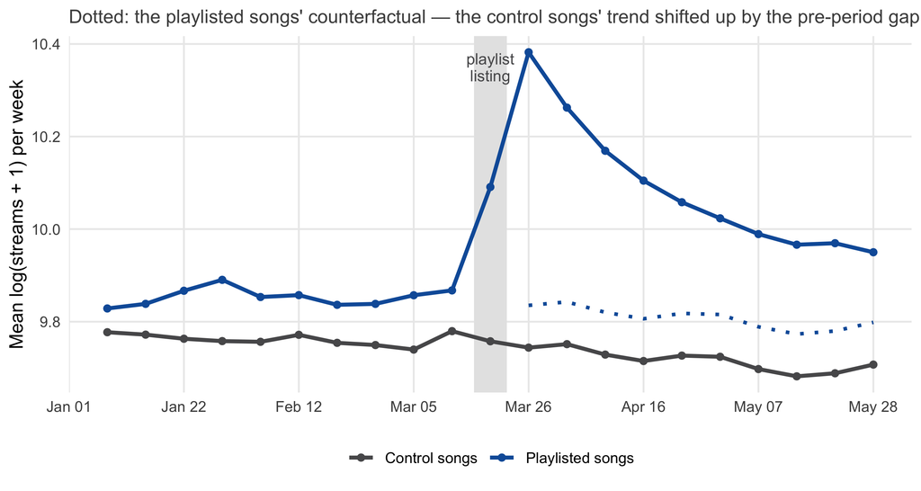

- **Real data:** 290 songs × 21 weeks
- March 19, 2018: **53 songs** added to a major playlist; 237 control songs
- Treated songs start **higher** → levels not comparable
- Before the listing: both groups move in **parallel**
- At the listing: the treated group **jumps**

Data: WU-RDS research project (github.com/WU-RDS/did).

## Two differences, one estimate

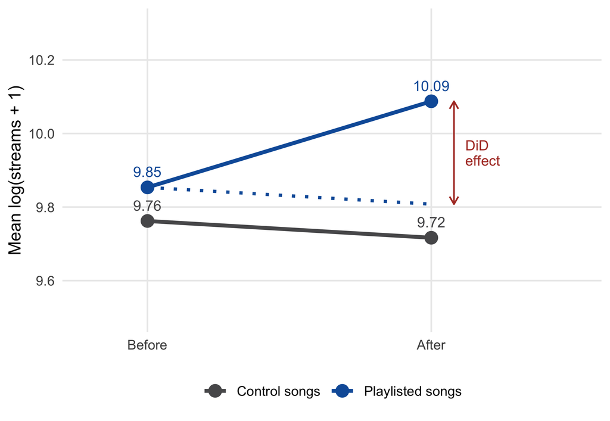

$$\text{DiD} = (\bar{y}_{T,\text{after}} - \bar{y}_{T,\text{before}}) - (\bar{y}_{C,\text{after}} - \bar{y}_{C,\text{before}})$$

(10.09 − 9.85) − (9.72 − 9.76) = **0.28** log points

The control group’s change estimates what would have happened to the treated songs **without** the listing — the counterfactual (dotted).

## The DiD regression

```r
did_data <- playlist |>
  filter(week != as.Date("2018-03-19")) |>          # drop the listing week
  mutate(log_streams = log(streams + 1))
model_did <- lm(log_streams ~ treated * post, data = did_data)
coef_table(model_did)
```

```
             Estimate Std. Error t value p-value
(Intercept)     9.762      0.018  545.86 < 0.001
treated         0.091      0.042    2.18   0.029
post           -0.046      0.025   -1.80   0.071
treated:post    0.280      0.059    4.73 < 0.001
```

| Coefficient | Meaning |
| --- | --- |
| `(Intercept)` 9.76 | Control, before: baseline |
| `treated` 0.09 | Treated, before: the **level difference** |
| `post` −0.05 | Control, after − before: the **common time trend** |
| `treated:post` **0.28** | The extra change of the treated songs: the **DiD effect** → ≈ **+32% streams** |

## The assumption: parallel trends

```r
placebo_data <- did_data |>
  filter(post == 0) |>
  mutate(fake_post = ifelse(week >= as.Date("2018-02-12"), 1, 0))
coef_table(lm(log_streams ~ treated * fake_post,
                data = placebo_data))["treated:fake_post", ]
```

```
                  Estimate Std. Error t value p-value
treated:fake_post    0.002      0.085    0.03   0.978
```

Without the listing, the treated songs would have followed the **same trend** as the controls. **Untestable** — but the pre-period makes it plausible: a fake listing in the pre-period shows **no effect**.

Live demo: course book, §5.10

https://wu-rds.github.io/MA2026/05-observational-data.html#sec-obs-did

## Your turn (5 min)

Add `major_label` as a control variable to the DiD regression:

```r
coef_table(lm(log_streams ~ treated * post + major_label, data = did_data))
```

Does the effect change? Then: name one situation in which the parallel-trends assumption would **fail** for playlist listings.

# What observational data can and cannot tell you

## Two strategies, one honest report

- **Adjustment** handles confounders you can **measure** — only as good as your proxies; “enough” is untestable
- **Difference-in-differences** handles confounders **constant over time** — needs parallel trends, plausible but never proven
- **Prediction** needs no causal assumptions — a good predictor is valuable even if no coefficient is an effect

Report effect + uncertainty + **assumptions**: “Adjusting for prior listening, tenure, Premium and device, adopters listen ≈ 4.5 hours more (95% CI 3.6–5.3), assuming no further differences affect listening — the experiment (3.2) suggests this is not fully met.”

## Assignment 3: analyzing observational data

- Your **personal** data (based on your student ID): an opt-in feature, promotion campaigns, and a small panel with a listing
- Tasks: naive vs. adjusted · categorical predictor · elasticity · logistic regression · DiD
- **Deadline:** Group A Sun, Nov 22 · Group B Wed, Nov 25
- **Debrief** at the start of the following session

**10 points:** report 7 + debrief 3. State your **assumptions** — the best answers say what the data *cannot* show.

## Learning check (Part II)

1. Log-log coefficient of ad spend = 0.15. Interpret. The level model says 0.8 sales per euro — why might the two disagree about doubling the budget?
2. Log-level model, dummy “promotion week” = 0.35. Percentage difference in sales — approximate and exact?
3. Residual plot shows a funnel. Consequence for coefficients, for *p*-values — and the simplest fix?
4. A DiD of a price promotion in treated stores: which assumption, and how can the pre-period help?

## Next session

**Module 6 · Mechanisms & heterogeneity** — *Why, and for whom, does it work?*

- Interaction effects: when the effect differs between groups (moderation)
- Mediation: through which mechanism an effect works
- In experiments and observational data — and in your group project